# tc2899_hw3_rmd

Thomas Carpino, tc2899

October 13, 2018

**## Problem 1: BRFSS**

Step 1: Import the dataset using the p8105 library:

Importing:

```r
#was running into CRAN errors so I added first two lines to alleviate problem
chooseCRANmirror(graphics = FALSE, ind = 1)
knitr::opts_chunk$set(echo = TRUE)

install.packages("devtools", force = TRUE)
devtools::install_github("p8105/p8105.datasets")
devtools::install_github("thomasp85/patchwork")
library(p8105.datasets)
library(tidyverse)
library(ggplot2)
library(patchwork)
library(ggridges)
```

*Step 2: Data Cleaning*

- format the data to use appropriate variable names;
- focus on the “Overall Health” topic
- include only responses from “Excellent” to “Poor”

Data Cleaning:

```r
#here I am cleaning the data and renaming the variables
brfss <- brfss_smart2010 %>%
  janitor::clean_names() %>%
  select(year, locationdesc, topic, response, data_value) %>%
  filter(topic == "Overall Health") %>%
  select(-topic) %>%
  rename("Overall Health Response" = response) %>%
  rename("Overall Health Value" = data_value) %>%
  separate(locationdesc, into = c("state", "county"), sep = " - ") %>%
  mutate(`Overall Health Response` = as.factor(`Overall Health Response`))
```

*The organizing responses from “Excellent” to “Poor” not successfu so I did not include this but I am including what I tried below:*

```r
# sort.brfss <- brfss %>%
  # brfss[order('Overall Health Response')]
```

Step 3: Answering the Questions

**In 2002, which states were observed at 7 locations?**

```r
brfss %>%
  filter(year == '2002') %>%
  group_by(state) %>%
  summarize(n = n_distinct(county)) %>%
  filter(n == 7)
```

```
## # A tibble: 3 x 2
##   state     n
##   <chr> <int>
## 1 CT        7
## 2 FL        7
## 3 NC        7
```

In 2002, 3 states were observed in 7 counties, including CT, FL, and NC.

**Make a “spaghetti plot” that shows the number of locations in each state from 2002 to 2010.**

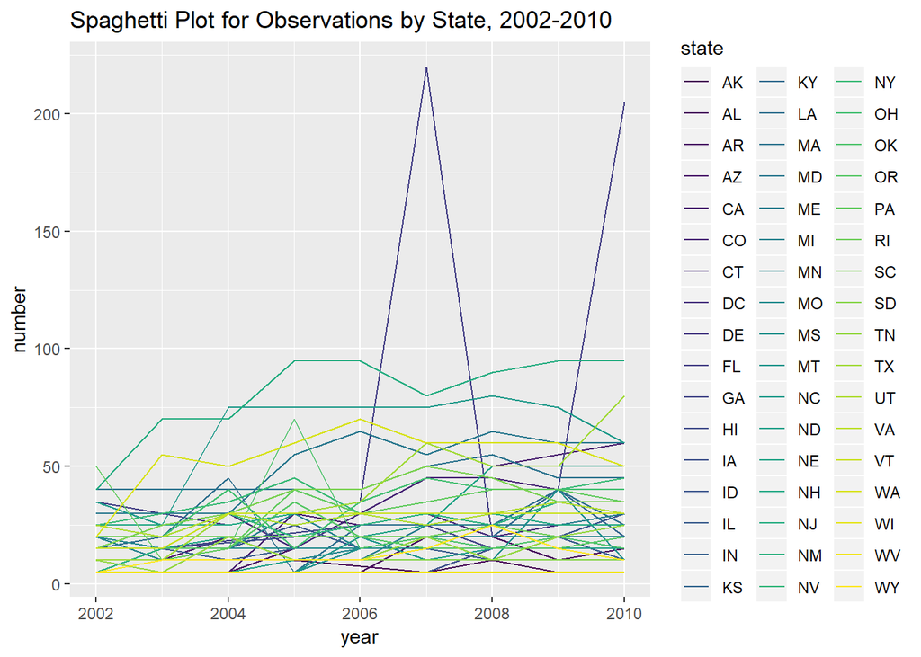

```r
#grouping first
brfss_plot = brfss %>%
  group_by(year, state) %>%
  summarize(number = n())

#plotting using the viridis package-- didn't really change much
ggplot(data = brfss_plot, aes(x = year, y = number, color = state)) + geom_line() + labs(title = "Spaghetti Plot for Observations by State, 2002-2010") + viridis::scale_color_viridis(
    name = "state",
    discrete = TRUE
)
```

**Make a table showing, for the years 2002, 2006, and 2010, the mean and standard deviation of the proportion of “Excellent” responses across locations in NY State.**

```r
#plotting the mean and st data across NY stat
brfss_2002_2006_2010 = brfss %>%
  filter(state == "NY") %>%
  filter(year == '2002' | year == '2006' | year == '2010') %>%
  group_by(year) %>%
  spread(key = "Overall Health Response", value = "Overall Health Value") %>%
  select(year, county, Excellent) %>%
  summarize(mean_excellent = mean(Excellent),
            sd_excellent = sd(Excellent))
brfss_2002_2006_2010
```

```
## # A tibble: 3 x 3
##    year mean_excellent sd_excellent
##   <int>          <dbl>        <dbl>
## 1  2002           24.0         4.49
## 2  2006           22.5         4.00
## 3  2010           22.7         3.57
```

**For each year and state, compute the average proportion in each response category (taking the average across locations in a state).**_

```r
brfss_avg_prop = brfss %>%
  spread(key = "Overall Health Response", value = "Overall Health Value") %>%
  group_by(year, state) %>%
  summarize(mean_excellent = mean(Excellent),
            mean_vgood = mean(`Very good`),
            mean_good = mean(Good),
            mean_fair = mean(Fair),
            mean_poor = mean(Poor))
brfss_avg_prop
```

```
## # A tibble: 443 x 7
## # Groups:   year [?]
##     year state mean_excellent mean_vgood mean_good mean_fair mean_poor
##    <int> <chr>          <dbl>      <dbl>     <dbl>     <dbl>     <dbl>
##  1  2002 AK              27.9       33.7      23.8      8.6       5.9
##  2  2002 AL              18.5       30.9      32.7     12.1       5.9
##  3  2002 AR              24.1       29.3      29.9     12.5       4.2
##  4  2002 AZ              24.1       33.4      29.4      8.9       4.25
##  5  2002 CA              22.7       29.8      28.7     14.3       4.5
##  6  2002 CO              23.1       32.5      30.3     11.2       2.92
##  7  2002 CT              29.1       33.8      25.0      8.73      3.43
##  8  2002 DC              29.3       31.8      28.1      8.3       2.4
##  9  2002 DE              20.9       34.2      29.8     11.1       4
## 10  2002 FL              25.7       31.1      28.9      9.67      4.53
## # ... with 433 more rows
```

Make a five-panel plot that shows, for each response category separately, the distribution of these state-level averages over time__

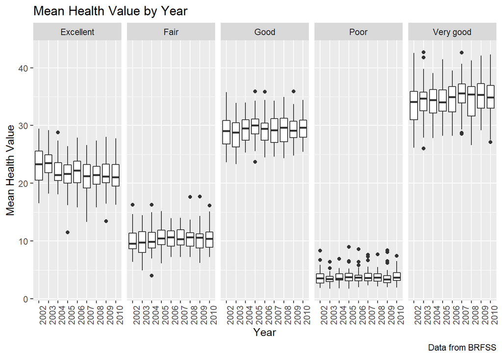

```r
#creating the 5 panel plo, using the viridis color technique... which did not change things really but still including it
brfss %>%
  mutate(year = as.factor(year)) %>%
  group_by(year, state, `Overall Health Response`) %>%
  summarize(mean = mean(`Overall Health Value`)) %>%
  ggplot(aes(x = year, y = mean)) +
  geom_boxplot() +
  labs( title = "Mean Health Value by Year", x = "Year", y = "Mean Health Value", caption = "Data from BRFSS"
) +
  facet_grid(~`Overall Health Response`) + theme(axis.text.x = element_text(angle = 90)) + viridis::scale_color_viridis(
    name = "Overall Health Value",
    discrete = TRUE
)
```

**## Problem 2: Instacart**

Step 1: Import the dataset using the p8105 library(done in problem 1):

```r
instacart = instacart %>%
  janitor::clean_names()

#showing myself what the data looks like
instacart
```

```
## # A tibble: 1,384,617 x 15
##    order_id product_id add_to_cart_ord~ reordered user_id eval_set
##       <int>      <int>            <int>     <int>   <int> <chr>
##  1        1      49302                1         1  112108 train
##  2        1      11109                2         1  112108 train
##  3        1      10246                3         0  112108 train
##  4        1      49683                4         0  112108 train
##  5        1      43633                5         1  112108 train
##  6        1      13176                6         0  112108 train
##  7        1      47209                7         0  112108 train
##  8        1      22035                8         1  112108 train
##  9       36      39612                1         0   79431 train
## 10       36      19660                2         1   79431 train
## # ... with 1,384,607 more rows, and 9 more variables: order_number <int>,
## #   order_dow <int>, order_hour_of_day <int>,
## #   days_since_prior_order <int>, product_name <chr>, aisle_id <int>,
## #   department_id <int>, aisle <chr>, department <chr>
```

Step 2: Exploratory Analysis

*The goal is to do some exploration of this dataset. To that end, write a short description of the dataset, noting the size and structure of the data, describing some key variables, and giving illstrative examples of observations.*

Step 3: Questions

- How many aisles are there, and which aisles are the most items ordered from?

```r
#grouping orders by isle
instacart %>%
    group_by(aisle_id) %>%
    summarize(n = n())
```

```
## # A tibble: 134 x 2
##    aisle_id     n
##       <int> <int>
##  1        1  2936
##  2        2  3873
##  3        3 17449
##  4        4  9917
##  5        5  2905
##  6        6  1795
##  7        7  1526
##  8        8  1501
##  9        9  9736
## 10       10   448
## # ... with 124 more rows
```

```r
#identifying the top three aisles using summary data
top_cart = instacart %>%
  group_by(aisle_id) %>%
  summarise(n = n()) %>%
  top_n(3)
top_cart
```

```
## # A tibble: 3 x 2
##   aisle_id      n
##      <int>  <int>
## 1       24 150473
## 2       83 150609
## 3      123  78493
```

There are 134 aisles, the most popular of which are aisles 83, 24, and 123.

- Make a plot that shows the number of items ordered in each aisle. Order aisles sensibly, and organize your plot so others can read it.

[figure not shown]

```r
#I made the plot but the aisles aren't very easily read
instacart %>%
  group_by(aisle) %>%
  summarize(n = n()) %>%
  ggplot(aes(x = aisle , y = n, color = aisle)) + geom_point() + labs(title = "Number of items ordered in each aisle") + theme(axis.text.x = element_text(angle = 90, size = 3))
```

+ Make a table showing the most popular item in each of the aisles “baking ingredients”, “dog food care”, and “packaged vegetables fruits”.

```r
pop_aisles = instacart %>%
  filter(aisle == 'baking ingredients' | aisle == 'dog food care' | aisle == 'packaged vegetables fruits') %>%
  select(product_name, aisle) %>%
  group_by(aisle, product_name) %>%
  summarise(n = n()) %>%
  arrange(desc(n))
#to sort highest to lowest the #(n) of each product within aisles

pop_aisles
```

```
## # A tibble: 1,444 x 3
## # Groups:   aisle [3]
##    aisle                      product_name                          n
##    <chr>                      <chr>                             <int>
##  1 packaged vegetables fruits Organic Baby Spinach               9784
##  2 packaged vegetables fruits Organic Raspberries                5546
##  3 packaged vegetables fruits Organic Blueberries                4966
##  4 packaged vegetables fruits Seedless Red Grapes                4059
##  5 packaged vegetables fruits Organic Grape Tomatoes             3823
##  6 packaged vegetables fruits Organic Baby Carrots               3597
##  7 packaged vegetables fruits Organic Baby Arugula               2923
##  8 packaged vegetables fruits Organic Peeled Whole Baby Carrots  2460
##  9 packaged vegetables fruits Red Raspberries                    1493
## 10 packaged vegetables fruits Clementines, Bag                   1478
## # ... with 1,434 more rows
```

```r
#to only show the top 1 aisles and its most popular product
pop_items = pop_aisles %>%
    group_by(aisle) %>%
    top_n(1)
pop_items
```

```
## # A tibble: 3 x 3
## # Groups:   aisle [3]
##   aisle                    product_name                                  n
##   <chr>                    <chr>                                     <int>
## 1 packaged vegetables fru~ Organic Baby Spinach                       9784
## 2 baking ingredients       Light Brown Sugar                           499
## 3 dog food care            Snack Sticks Chicken & Rice Recipe Dog T~    30
```

- Make a table showing the mean hour of the day at which Pink Lady Apples and Coffee Ice Cream are ordered on each day of the week; format this table for human readers (i.e. produce a 2 x 7 table)

```r
apple_icecream = instacart %>%
  filter(product_name == 'Pink Lady Apples' | product_name == 'Coffee Ice Cream') %>%
  mutate(order_dow = as.character(order_dow)) %>%
  mutate(order_dow = recode(order_dow, `0` = "0:Sunday", `1` = "1:Monday", `2` = "2:Tuesday", `3` ="3:Wednesday", `4` = "4:Thursday", `5` = "5:Friday", `6` = "6:Saturday")) %>%
  group_by(order_dow, product_name) %>%
  #recoding (order_dow, `0` = "Sunday", 1 = "Monday", 2 = "Tuesday", 3 ="Wednesday", 4 = "Thursday", 5 = "Friday", 6 = "Saturday") %>%
  summarize(mean_hr = mean(order_hour_of_day)) %>%
  spread(key = order_dow, value = mean_hr) %>%
  knitr::kable(digits = 1)
apple_icecream
```

| product_name | 0:Sunday | 1:Monday | 2:Tuesday | 3:Wednesday | 4:Thursday | 5:Friday | 6:Saturday |
| --- | --- | --- | --- | --- | --- | --- | --- |
| Coffee Ice Cream | 13.8 | 14.3 | 15.4 | 15.3 | 15.2 | 12.3 | 13.8 |
| Pink Lady Apples | 13.4 | 11.4 | 11.7 | 14.2 | 11.6 | 12.8 | 11.9 |

**## Problem 3: NY NOAA**

Step 1: Import the dataset using the p8105 library(done in problem 1):

```r
#showing myself dataset
ny_noaa
```

```
## # A tibble: 2,595,176 x 7
##    id          date        prcp  snow  snwd tmax  tmin
##    <chr>       <date>     <int> <int> <int> <chr> <chr>
##  1 US1NYAB0001 2007-11-01    NA    NA    NA <NA>  <NA>
##  2 US1NYAB0001 2007-11-02    NA    NA    NA <NA>  <NA>
##  3 US1NYAB0001 2007-11-03    NA    NA    NA <NA>  <NA>
##  4 US1NYAB0001 2007-11-04    NA    NA    NA <NA>  <NA>
##  5 US1NYAB0001 2007-11-05    NA    NA    NA <NA>  <NA>
##  6 US1NYAB0001 2007-11-06    NA    NA    NA <NA>  <NA>
##  7 US1NYAB0001 2007-11-07    NA    NA    NA <NA>  <NA>
##  8 US1NYAB0001 2007-11-08    NA    NA    NA <NA>  <NA>
##  9 US1NYAB0001 2007-11-09    NA    NA    NA <NA>  <NA>
## 10 US1NYAB0001 2007-11-10    NA    NA    NA <NA>  <NA>
## # ... with 2,595,166 more rows
```

Step 2: Exploratory Analysis

The goal is to do some exploration of this dataset. To that end, write a short description of the dataset, noting the size and structure of the data, describing some key variables, and indicating the extent to which missing data is an issue.

Step 3: Questions

- Do some data cleaning. Create separate variables for year, month, and day. Ensure observations for temperature, precipitation, and snowfall are given in reasonable units. For snowfall, what are the most commonly observed values? Why?

```r
#cleaning dataset
clean_noaa = ny_noaa %>%
  janitor::clean_names() %>%
  na.omit() %>%
  separate(date, into = c("year", "month", "day"), sep = "-") %>%
  mutate(tmin = as.numeric(tmin)) %>%
  mutate(tmax = as.numeric(tmax))

#creating new dataset of snow amount
snow = clean_noaa %>%
  group_by(snow) %>%
  summarise(n = n()) %>%
  top_n(3)
snow
```

```
## # A tibble: 3 x 2
##    snow       n
##   <int>   <int>
## 1     0 1112758
## 2    13   12460
## 3    25   15809
```

The most common amount of snow on a givn day in New York is 0 units. This makes sense because it is normally not snowing in New York, out of the 365 days per year.

- Make a two-panel plot showing the average max temperature in January and in July in each station across years. Is there any observable / interpretable structure? Any outliers?

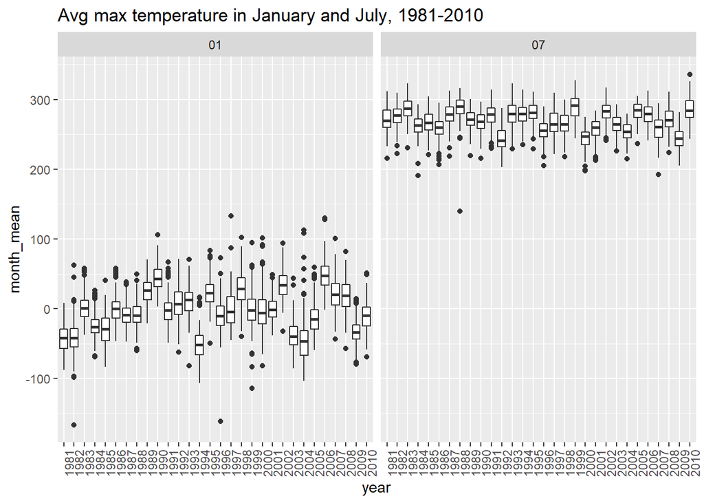

```r
#creating new dataset
jan_july = clean_noaa %>%
    select(year, month, id, tmin, tmax) %>%
    filter(month == '01' | month == '07') %>%
    mutate(year = as.factor(year)) %>%
    group_by(year, month, id) %>%
    summarize(month_mean = mean(tmax)) %>%
    ggplot(aes(x = year, y = month_mean)) + geom_boxplot() + labs(title = "Avg max temperature in January and July, 1981-2010") + facet_grid(.~ month) + theme(axis.text.x = element_text(angle = 90))
#showing self dataset
jan_july
```

- Make a two-panel plot showing (i) tmax vs tmin for the full dataset (note that a scatterplot may not be the best option); and (ii) make a plot showing the distribution of snowfall values greater than 0 and less than 100 separately by year.

[figure not shown]

```r
#setup
library(ggplot2)
library(patchwork)

#part 1
min_max = clean_noaa %>%
  select(tmin, tmax)

min_max_plot = ggplot(min_max, aes(x = tmin, y = tmax)) + geom_hex() + labs(title = "tmax vs tmin for the full dataset")
min_max_plot
```

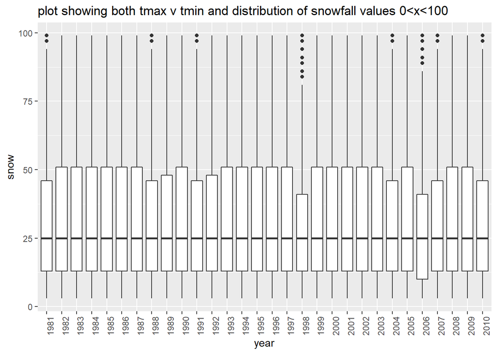

```r
#part 2
snowfall = clean_noaa %>%
    select(year, snow) %>%
    filter(snow < 100, snow > 0)

snowfall_plot = ggplot(snowfall, aes(x = year, y = snow)) + geom_boxplot() + labs(title = "plot showing both tmax v tmin and distribution of snowfall values 0<x<100") + theme(axis.text.x = element_text(angle = 90))

snowfall_plot
```

[figure not shown]

```r
min_max_plot + snowfall_plot
```